# Estatística para ciência de dados

**Aluno:** Eduardo Façanha Dutra

**Matrícula:** 2016473

**Resolução do trabalho 03: Ex3-teste-normalidade - duas variáveis**

Objetivos: Analisar a distribuição da amostra Transformar a distribuição dos dados da amostra em uma distribuição lognormal – os valores em logaritmos seguem a DN

Considere o caso em que o tempo do usuário é a variável independente (calculada) e representando o tempo que o usuário passou em uma determinada conferência virtual, quando fez uso de um dos Meet virtuais, se usando Zoom ou Hangout. A hipótese é saber se existe diferença significativa entre os dois Meet. O arquivo segue os seguintes princípios para a realização deste trabalho: - independência dos dados, quem usou um meet não usou o outro. - A variável tempo é mais próxima de uma log normalidade, porque a medida que o usuário usa um sistema, ele se torna mais especialista e o tempo, no eixo X tende a diminuir com o tempo.

Obs: In a test statistic: the result expresses in a single number how much my data differ from my null hypothesis. So it indicates to what extent the observed scores deviate from a normal distribution. Now, if my null hypothesis is true, then this deviation percentage should probably be quite small. That is, a small deviation has a high probability value or p-value. Reversely, a huge deviation percentage is very unlikely and suggests that my reaction times don’t follow a normal distribution in the entire population. So a large deviation has a low p-value. As a rule of thumb, we reject the null hypothesis if p < 0.05. So if p < 0.05, we don’t believe that our variable follows a normal distribution in our population.

Pede-se: Teste a normalidade da amostra da variável Tempo, realizando as duas técnicas dadas a seguir e considerando que:

1. a técnica Shapiro-wilk permite testar a normalidade, para uma amostra pequena
2. a técnica Kolmogorov-Smirnov permite testar a lognormalidade da amostra.
3. Visualize os dados usando Boxplot, histograma e qqnorm.

Senão houver normalidade da amostra, então transforme os dados em uma log normal, depois, verifique como ficaram os dados, e repeta os testes, dos passos 1 ao 3.

Para saber mais assista o vídeo: https://www.sigmamagic.com/blogs/how-to-interpret-skewness-and-kurtosis/

**Resolução:**

A resolução da atividade seguirá o seguinte roteiro:

1- Leitura dos dados e inicialização das variáveis;

2- Visualização dos gráficos e cálculo de assimetria e curtose dos conjuntos de dados;

Para realizar o teste de normalidade analisar os dados serão plotados os gráficos pertinentes,

**1 - Leitura dos dados e inicialização das variáveis:**

```r
library(readr)
#Leitura do arquivo CSV
meet_file <- read_csv("Dados/meet-file.csv", #caminho do arquivo
                      col_types = cols(Meet = col_factor(levels = c("Zoom", #configuração das colunas da tabela
                                                                "Hangout")),
                                                          Subject = col_skip()))
#seleção dos dados que representam a plataforma Zoom
Zoom = meet_file[meet_file$Meet == "Zoom","Tempo"]

#seleção dos dados que representam a plataforma Hangout
Hangout = meet_file[meet_file$Meet == "Hangout","Tempo"]


#Função para configuração dos gráficos
library(ggplot2)
library(cowplot)

gera_histograma <- function(dados, bins=9){

n = length(dados$Tempo)
nome <- deparse(substitute(dados))
mediaAmostra<-mean(dados$Tempo)
sd<-sqrt(var(dados$Tempo)*(n-1)/n)

histograma <- ggplot(dados,aes(Tempo))
histograma <- histograma + geom_histogram(bins = bins, aes(y=..density.., fill=..count..))+geom_density()
histograma <- histograma + labs( x="",y="Frequência", title=paste("Tempo utilizado por usuário na plataforma",nome))
histograma <- histograma + scale_fill_gradient("Amostra por caixa", low="#DCDCDC", high="#7C7C7C",)
histograma <- histograma + stat_function(fun=dnorm, color="red", args=list(mean=mediaAmostra, sd=sd))

ylimHist= layer_scales(histograma)$x$range$range

diagCaixa <- ggplot(dados, aes(y=Tempo))
diagCaixa <- diagCaixa + geom_boxplot()
diagCaixa <- diagCaixa + theme(axis.title.y=element_blank(),axis.text.y=element_blank(),axis.ticks.y=element_blank())
diagCaixa <- diagCaixa + labs(y=paste("Tempo de uso do",nome))
diagCaixa <- diagCaixa + coord_flip(ylim = ylimHist)

plot_grid(histograma, diagCaixa,
                   ncol = 1, rel_heights = c(2, 1),
                   align = 'v', axis = "rlbt")  }
```

**2 - Cálculo de assimetria e curtose dos conjuntos de dados, e visualização dos gráficos**

**2.1 - Plataforma Zoom:**  
Cálculo da curtose e assimetria:

O cálculo da curtose e assimetria de uma amostra se dá utilizando o quarto e terceiro momentos centrais, respectivamente, ajustados para dados amostrais.

```r
library(e1071)
curtoseZoom <- kurtosis(Zoom$Tempo)
assimetriaZoom <- skewness(Zoom$Tempo)
cat(" Curtose para as amostras que utilizaram a plataforma Zoom: ", curtoseZoom,"\n","Assimetria para as amostras que utilizaram a plataforma Zoom: ", assimetriaZoom)
```

```
 Curtose para as amostras que utilizaram a plataforma Zoom:  3.208934
 Assimetria para as amostras que utilizaram a plataforma Zoom:  1.617429
```

**Comentário:**

A partir da curtose calculada pode-se afirmar que a distribuição é mais concentrada em torno de um valor, o que faz com que a distribuição amostral possa ser caracterizada como **leptocúrtica**.

A partir da assimetria calculada pode-se afirmar que a distribuição possui uma **assimetria positiva**, o que faz com que a distribuição possua uma cauda mais longa à direita.

Desenho dos gráficos para a plataforma Zoom:

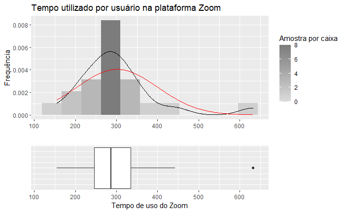

```r
gera_histograma(Zoom,bins= 11)
```

**Comentário:**

Foi plotado um diagrama de caixas, um histograma com 11 caixas (bins), valor selecionado empiricamente, e uma curva gaussiana com a média e desvio padrão iguais aos da amostra de tempo utilizado na ferramenta Zoom, para utilizar como referência visual.

O gráfico do histograma mostra que a amostra segue aparentemente uma distribuição normal, exceto pelo valor extremo à direita, pois: observa-se que a média da gaussiana e a barra com maior frequência e número de observações aparentemente coincidem, e o número de observações ao redor da média e sua frequência são similares.

O valor extremo à direita faz com que haja uma **assimetria positiva** na amostra.

Quanto à curtose do histograma, observa-se que os valores estão afunilados em torno da média e acima da curva normal, justificando a **curtose positiva** calculada.

```r
library(e1071)
curtoseHangout <- kurtosis(Hangout$Tempo)
assimetriaHangout <- skewness(Hangout$Tempo)
cat(" Curtose para as amostras que utilizaram a plataforma Hangout: ", curtoseHangout,"\n","Assimetria para as amostras que utilizaram a plataforma Hangout: ", assimetriaHangout)
```

```
 Curtose para as amostras que utilizaram a plataforma Hangout:  -0.6120307
 Assimetria para as amostras que utilizaram a plataforma Hangout:  0.8665088
```

**Comentário:**

A partir da assimetria calculada pode-se afirmar que a distribuição possui uma **assimetria positiva**, o que faz com que a distribuição possua uma cauda mais longa à direita.

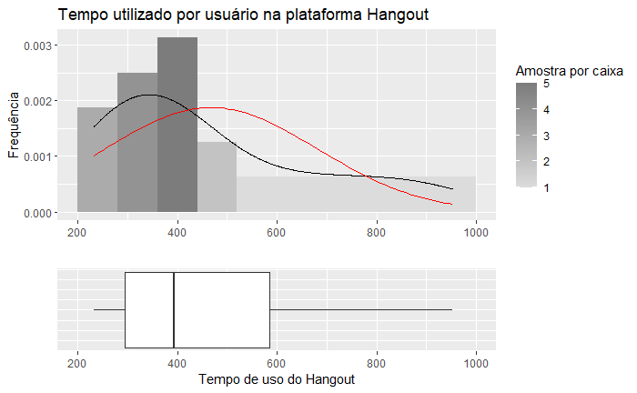

```r
gera_histograma(Hangout, bins= 10)
```

**Comentário:** Como no gráfico anterior, foi plotado um diagrama de caixas, um histograma de 10 caixas e uma curva gaussiana para comparação. O gráfico nos revela que a amostra não segue aparentemente uma distribuição normal, pois: observa-se que a média da gaussiana e a barra com maior frequência e número de observações não coincidem, com um número de observações muito concentrado à esquerda do gráfico e uma longa cauda à direita, o que revela a **assimetria positiva** da amostra.

Quanto à curtose da amostra, devido a acentuada assimetria no gráfico não foi possível estimar visualmente se há uma curtose positiva ou negativa.

A seguir é montada uma tabela com a estatística descritiva do conjunto de dados para confirmar e obter uma medida precisa das características analisadas.

```r
library(magrittr)
library(psych)
library(dplyr)

describeZoom <- meet_file[meet_file$Meet == "Zoom",]%>%describe(trim = 0.0)%>%slice(2:n())%>%`rownames<-`("Tempo uso Zoom")

describeHangout <-meet_file[meet_file$Meet == "Hangout",]%>%describe(trim = 0)%>%slice(2:n())%>%`rownames<-`("Tempo uso Hangout")

tabelaDescricao <- rbind(describeZoom, describeHangout)[,c("skew","kurtosis")]

tabelaDescricao
```

|  | skew | kurtosis |
| --- | --- | --- |
| Tempo uso Zoom | 1.6174294 | 3.2089344 |
| Tempo uso Hangout | 0.8665088 | -0.6120307 |

**Comentário:** Observa-se que os assimetria (skew) e a curtose (kurtosis) estão fora dos valores da curva padrão normal(que deve ser 0.0 para curtose e assimetria). Mesmo com esses resultados indicando que a amostra pode ter sido retirada de uma população que não segue uma curva normal, é necessário realizar os testes de normalidade, pois os valores obtidos podem ser devido ao tamanho da amostra, que pode não ter sido suficiente para indicar a real tendência da população.

```r
shapiro.test(meet_file[meet_file$Meet == "Zoom",]$Tempo)
```

```
    Shapiro-Wilk normality test

data:  meet_file[meet_file$Meet == "Zoom", ]$Tempo
W = 0.84372, p-value = 0.004191
```

```r
ks.test(fit)
```

[output not shown]